# Construction of Global Balanced Index Fund

André le Roux

November 2024

### Abstract

This article will discuss the process through which a portfolio was constructed from a mix of traded global indexes that takes into account several constraints in it’s construction.

# Data

The Data used in this article consists of a number of global traded indexes which include indexes of currencies, bonds, credit, equities and commodities. The data included each indexes daily price.

# Analysis

The first table is the optimal weightings of assets as of the most recent date in the data, looking at the past 3 years of data. These weight have been optimised to conform to the following constraints. Individual asset weighting can not exceed 40% or be less than 0%, bonds and credit indexes can not make up more than 25% and Equities can not make up more than a combined 60%.

##### Table 1:

Table 1: Optimal Portfolio Weights in 2021

| Assets | Weights | Category |
| --- | --- | --- |
| Asia_dollar_Idx | 0.00 | Other |
| Bbg_EUCorpCred_Unhedged_USD | 0.00 | Bonds & Credit |
| Bbg_EuroBonds_UnhedgedEUR | 0.00 | Bonds & Credit |
| Bbg_GlBonds_HedgedUSD | 0.00 | Bonds & Credit |
| Bbg_GlCorpCred_Hedged_USD | 0.00 | Bonds & Credit |
| Bbg_USBonds_UnhedgedUSD | 0.00 | Bonds & Credit |
| Bbg_USCorpCred_Unhedged_USD | 0.25 | Bonds & Credit |
| Commod_Idx | 0.15 | Other |
| Dollar_Idx | 0.00 | Other |
| MSCI_ACWI | 0.20 | Equities |
| MSCI_Jap | 0.00 | Equities |
| MSCI_RE | 0.00 | Equities |
| MSCI_USA | 0.40 | Equities |

We can see in *table 1* that the latest optimal portfolio consists of 25% US Credit; 15% Commodities; 20% of the All Country World Index and 40% in the US equity market. This portfolio was solved using mean-variance optimisation.

In order to check how liable these weights are to change I ran a rebalancing time frame across the available historical data, measuring three years into the past at each point and optimising the weights. *Figure 1* displays my results.

##### Figure 1:

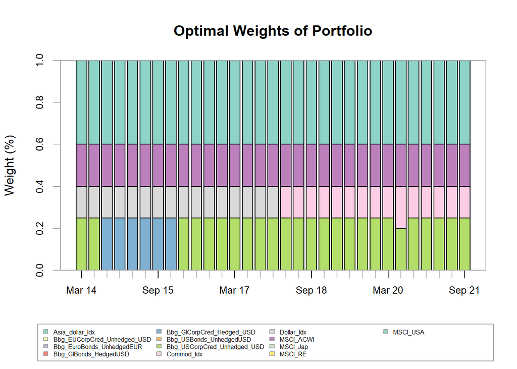

When looking at historical rebalancing it appears that there have been shifts between assets at certain rebalancing days.

# Conclusion

When designing an optimal portfolio for traded global indexes we find an equilibrium weighting vector that provides the optimal mean-variance trade off within the given constraints.